# PSTAT231_Project_AO_XU

AO XU

2022-12-09

# 1. Introduction

Building a machine learning algorithm that can forecast the iris species is the goal of this project. To produce the best accurate model for the classification task, we will use data from Kaggle and employ a number of strategies. We collect the data set from kaggle.

## 1.1 What is Iris?

Iris is a genus of flowering plants with 310 recognized species with colorful blooms. Iris is both the common name and the scientific name for all species of Iris, as well as some species from other closely related genera. Some species go by the common name “flags,” and the plants of the subgenus Scorpiris are sometimes referred to as “junos,” especially in gardening. It is a well-liked garden bloom.

In our data set, there are three kinds of species - Iris-setosa, Iris-versicolor and Iris-virginica.

## 1.2 Why is this model relevant?

It can predict the species of iris from the data about widths and lengths about sepal and petal.

# 2. Data collection and cleaning

## 2.1 Library Loading

For this part, all libraries which will be used are shown here.

```r
library(tidymodels)
library(discrim)
```

```r
library(poissonreg)
library(corrr)
tidymodels_prefer()
suppressMessages(library(tidyquant))
library(ggplot2)
library(fitdistrplus)
library(reshape2)
library(patchwork)
library(parallel)
library(tidyverse)
library(janitor)
library(here)
library(corrr)
library(kableExtra)
library(corrplot)
```

## 2.2 Loading and Exploring Raw Data

For this part, the raw data is shown here. We clean the data set by setting species from “Iris-setosa”, “Iris-versicolor” and “Iris-virginica” to 0, 1 and 2.

```r
set.seed(3435) # can be any number

iris <- read_csv(file = "iris.csv") %>%
  na.omit() %>%
  mutate(Species = case_when(Species == "Iris-setosa" ~ 0,
                             Species == "Iris-versicolor" ~ 1,
                             Species == "Iris-virginica" ~ 2)) %>%
  clean_names()
iris$species <- as.factor(iris$species)
iris
```

```
## # A tibble: 150 × 6
##       id sepal_length_cm sepal_width_cm petal_length_cm petal_width_cm species
##    <dbl>           <dbl>          <dbl>           <dbl>          <dbl> <fct>
##  1     1             5.1            3.5             1.4            0.2 0
##  2     2             4.9            3               1.4            0.2 0
##  3     3             4.7            3.2             1.3            0.2 0
##  4     4             4.6            3.1             1.5            0.2 0
##  5     5             5              3.6             1.4            0.2 0
##  6     6             5.4            3.9             1.7            0.4 0
##  7     7             4.6            3.4             1.4            0.3 0
##  8     8             5              3.4             1.5            0.2 0
##  9     9             4.4            2.9             1.4            0.2 0
## 10    10             4.9            3.1             1.5            0.1 0
## # … with 140 more rows
```

## 2.3 Splitting the data into training set and testing set

We split the data into training set and testing set for 0.8.

```r
iris_split <- iris %>%
  initial_split(strata = species, prop = 0.8)
iris_train <- training(iris_split)
iris_test <- testing(iris_split)
```

```r
dim(iris_train)
```

```
## [1] 120   6
```

```r
dim(iris_test)
```

```
## [1] 30  6
```

# 3. Explorarotory Data Analysis

## 3.1 Correlation

This is about the correlation between width and lengths of sepal and petal of iris.

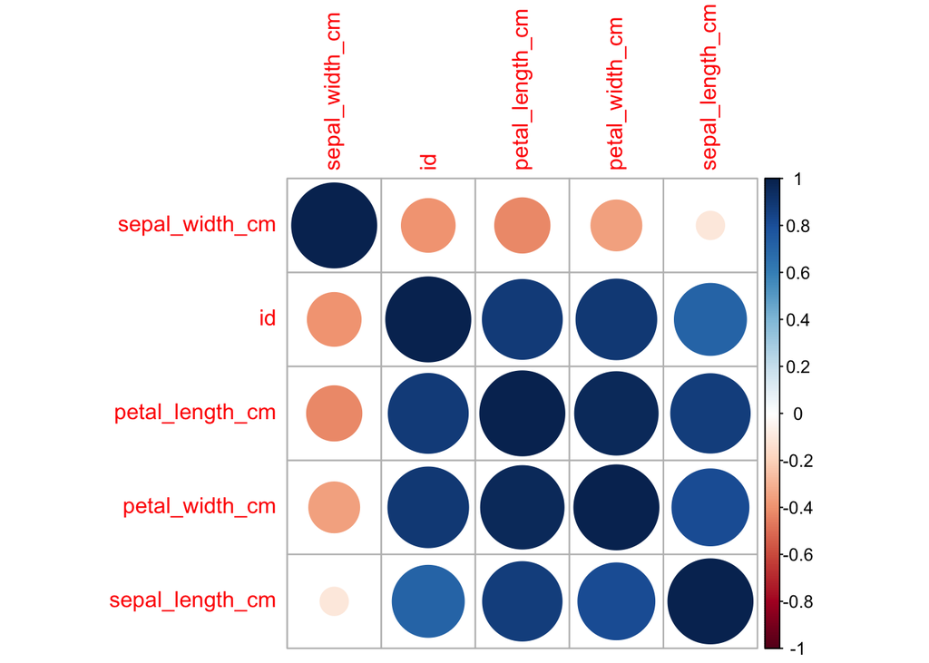

```r
iris_numer <- iris %>%
  select_if(is.numeric)

iris_cor <- cor(iris_numer)
iris_cor_plot <- corrplot(iris_cor,
                               order = 'AOE')
```

## 3.2 Relationship between sepal length and species

From this part we could find that if sepal length is lower, than it probably be Iris-setosa; if sepal length is higher, than it probably be Iris-virginica; Otherwise, it probably would be Iris-versicolor.

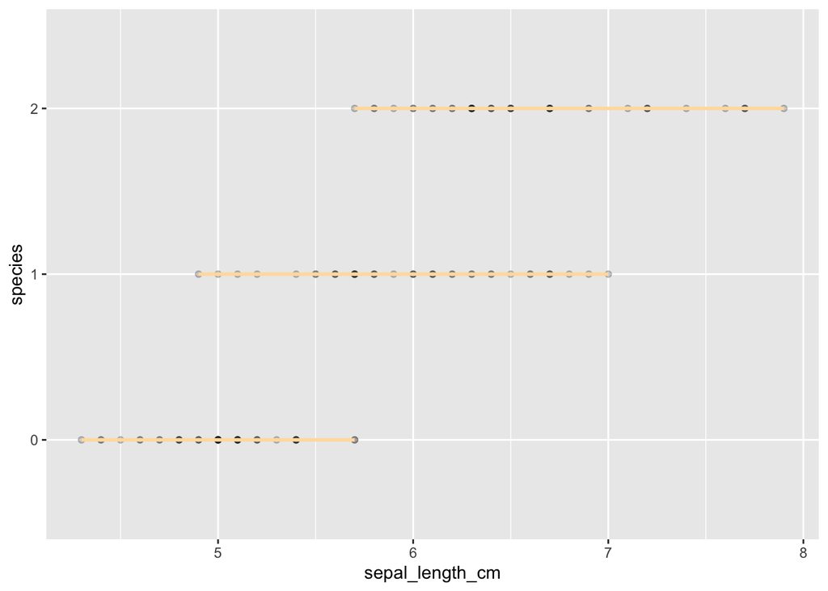

```r
iris_train %>%
  ggplot(aes(x=sepal_length_cm, y=species)) +
  geom_point(alpha = 0.2) +
  geom_smooth(method = 'lm', formula = 'y ~ x',colour = "navajowhite")
```

## 3.3 Relationship between sepal width and species

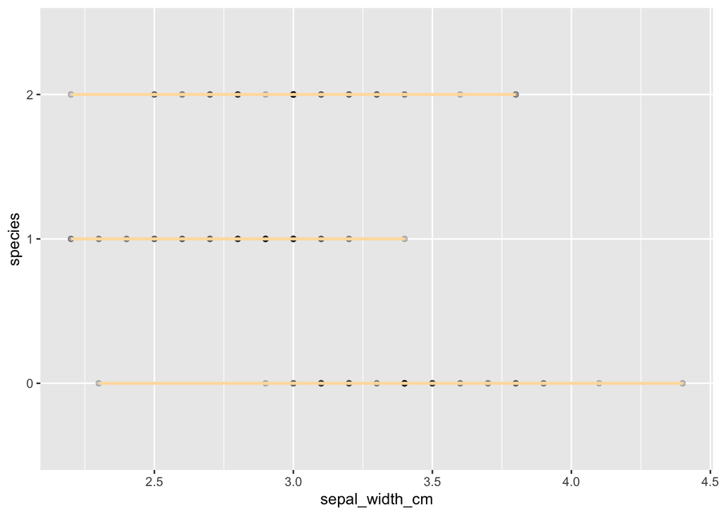

```r
iris_train %>%
  ggplot(aes(x=sepal_width_cm, y=species)) +
  geom_point(alpha = 0.2) +
  geom_smooth(method = 'lm', formula = 'y ~ x',colour = "navajowhite")
```

## 3.4 Relationship between petal length and species

From this part we could find that if petal length is lower, than it probably be Iris-setosa; if sepal length is higher, than it probably be Iris-virginica; Otherwise, it probably would be Iris-versicolor.

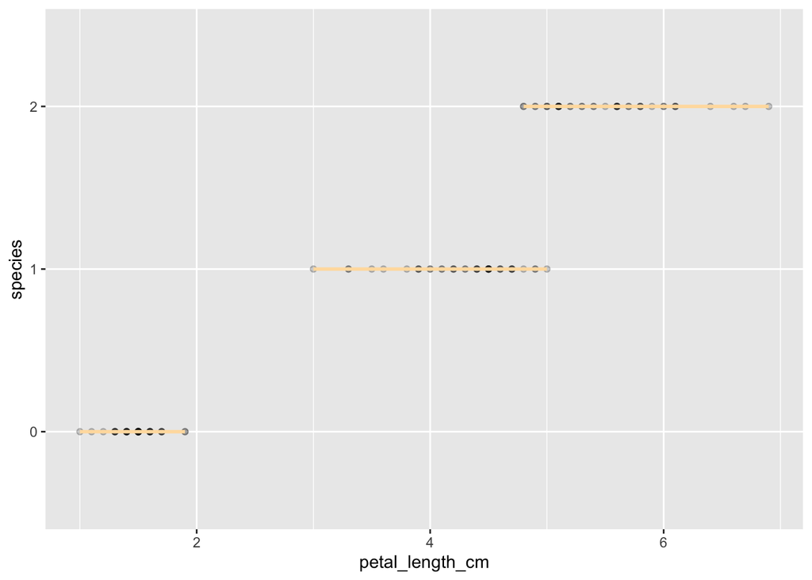

```r
iris_train %>%
  ggplot(aes(x=petal_length_cm, y=species)) +
  geom_point(alpha = 0.2) +
  geom_smooth(method = 'lm', formula = 'y ~ x',colour = "navajowhite")
```

## 3.5 Relationship between petal width and species

From this part we could find that if petal width is lower, than it probably be Iris-setosa; if sepal length is higher, than it probably be Iris-virginica; Otherwise, it probably would be Iris-versicolor.

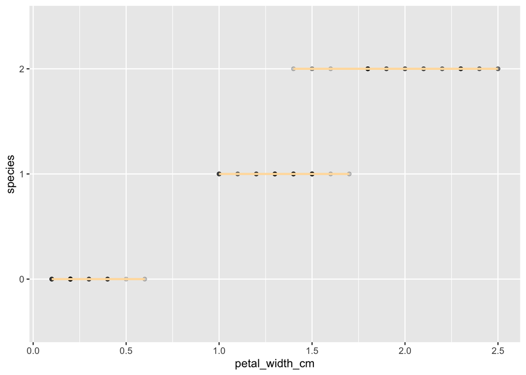

```r
iris_train %>%
  ggplot(aes(x=petal_width_cm, y=species)) +
  geom_point(alpha = 0.2) +
  geom_smooth(method = 'lm', formula = 'y ~ x',colour = "navajowhite")
```

## 3.6 Distribution of Species

This is our histograms of our three species, and we could find that they are equally distributed in our dataset.

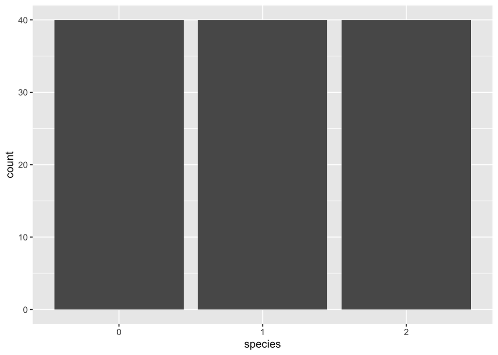

```r
iris_train %>%
  ggplot(aes(x =species)) +
  geom_bar()
```

# 4. Model Fitting

## 4.1 Create Recipes

For this part, we create recipes.

```r
iris_recipe <-
  recipe(species ~ sepal_length_cm + sepal_width_cm + petal_length_cm + petal_width_cm,
         data = iris) %>%
  step_dummy(all_nominal_predictors()) %>%
  step_center(all_predictors()) %>%
  step_scale(all_predictors())
```

## 4.2 Set Folds

For this part, we create folds and set k to be 5..

```r
iris_folds <- vfold_cv(iris_train, strata = species,
                          v = 5)
```

## 4.3 Construct Models

In this part, we construct lasso boost, random_forest and knn to fit our data. After that we storage them in environment by creating srcipts individually.

```r
library(tidymodels)
library(discrim)
library(poissonreg)
library(corrr)
tidymodels_prefer()
suppressMessages(library(tidyquant))
library(ggplot2)
library(fitdistrplus)
library(reshape2)
library(patchwork)
library(parallel)
library(kableExtra)

set.seed(3435) # can be any number

iris <- read_csv(file = "iris.csv") %>%
  na.omit() %>%
  mutate(Species = case_when(Species == "Iris-setosa" ~ 0,
                             Species == "Iris-versicolor" ~ 1,
                             Species == "Iris-virginica" ~ 2)) %>%
  clean_names()
iris$species <- as.factor(iris$species)

iris_split <- iris %>%
  initial_split(strata = species, prop = 0.8)
iris_train <- training(iris_split)
iris_test <- testing(iris_split)

iris_recipe <-
  recipe(species ~ sepal_length_cm + sepal_width_cm + petal_length_cm + petal_width_cm,
         data = iris) %>%
  step_dummy(all_nominal_predictors()) %>%
  step_center(all_predictors()) %>%
  step_scale(all_predictors())

iris_folds <- vfold_cv(iris_train, strata = species,
                       v = 5)

iris_lasso_spec <- multinom_reg(penalty = tune(),
                                mixture = tune()) %>%
  set_mode("classification") %>%
  set_engine("glmnet")

iris_workflow <- workflow() %>%
  add_recipe(iris_recipe) %>%
  add_model(iris_lasso_spec)

iris_grid <- grid_regular(penalty(range = c(-5, 5)),
                          mixture(range = c(0, 1)), levels = 10)

tune_res <- tune_grid(
  iris_workflow,
  resamples = iris_folds,
  grid = iris_grid
)

bestpenalty <- select_best(tune_res,metrix="roc_auc")
bestpenalty

lasso_final<-finalize_workflow(iris_workflow,bestpenalty)

lasso_final_fit <- fit(lasso_final, data = iris_train)

boost_spec <- boost_tree(trees = c(1,10), tree_depth = 4) %>%
  set_engine("xgboost") %>%
  set_mode("classification")
param_grid_boost <- grid_regular(trees(range = c(1, 10)),  levels = 5)

boost_workflow <- workflow() %>%
  add_model(boost_spec %>% set_args(trees = tune())) %>%
  add_recipe(iris_recipe)

tune_res_boost <- tune_grid(
  boost_workflow,
  resamples = iris_folds,
  grid = param_grid_boost,
  metrics = metric_set(roc_auc)
)

boost_preformance <- collect_metrics(tune_res_boost)

final_boost <- select_best(tune_res_boost, metric = "roc_auc")

final_workflow_boost <- finalize_workflow(boost_workflow, final_boost)

final_fit_boost <- fit(final_workflow_boost, data = iris_train)

forest <- rand_forest() %>%
  set_engine("ranger", importance="impurity") %>%
  set_mode("classification") %>%
  set_args(mtry = tune(),trees = tune(), min_n = tune())
forest

forest_workflow <- workflow() %>%
  add_model(forest %>% set_args(mtry = tune(), trees = tune(),
                                min_n = tune())) %>%
  add_recipe(iris_recipe)
#forest_workflow
param_grid2<-grid_regular(mtry(range = c(1, 4)),
                          trees(range = c(1,4)),
                          min_n(range = c(1,4)),
                          levels = 4)
param_grid2

#install.packages("ranger")
tune_res_forest<-tune_grid(
  forest_workflow,
  resamples = iris_folds,
  grid = param_grid2,
  metrics = metric_set(roc_auc)
)

best_random<-select_best(tune_res_forest,metrix="roc_auc")
best_random

random_final<-finalize_workflow(forest_workflow, best_random)

random_final_fit <- fit(random_final, data = iris_train)

knn_spec <-nearest_neighbor() %>%
  set_mode("classification") %>%
  set_engine("kknn") %>%
  set_args(neighbors = tune())

translate(knn_spec)

knn_workflow <- workflow() %>%
  add_recipe(iris_recipe) %>%
  add_model(knn_spec)

knn_params <- parameters(knn_spec)

knn_grid <- grid_regular(knn_params, levels = 5)

tune_res_knn <- tune_grid(
  knn_workflow,
  resamples = iris_folds,
  grid = knn_grid
)

autoplot(tune_res_knn)

# knn_roc <- collect_metrics(tune_res_knn) %>%
  # dplyr::select(.metric, mean, std_err)

# knn_roc

bestknn <- select_best(tune_res_knn,metrix="roc_auc")
bestknn

knn_final <- finalize_workflow(knn_workflow, bestknn)

knn_final_fit <- fit(knn_final, data = iris_train)
```

We have stored our models in the scripts and we load them.

```r
load("~/Documents/2022Fall/Pstat131/PSTAT231/lasso.RData")
load("~/Documents/2022Fall/Pstat131/PSTAT231/boost.RData")
load("~/Documents/2022Fall/Pstat131/PSTAT231/random_forest.RData")
load("~/Documents/2022Fall/Pstat131/PSTAT231/knn.RData")
```

## 5 Compare Models

## 5.1 Autoplots

#### Plot of Lasso

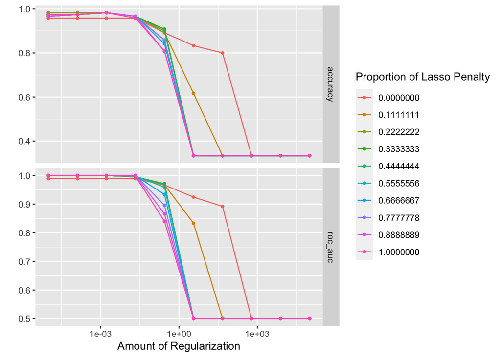

```r
autoplot(tune_res)
```

#### Plot of Boost Trees

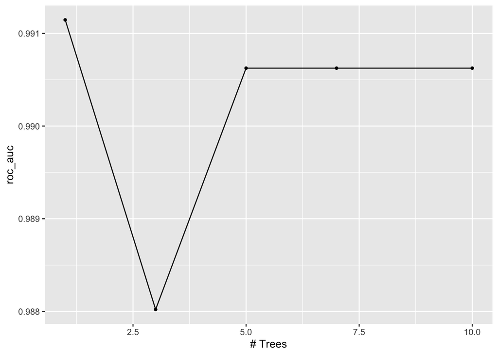

```r
autoplot(tune_res_boost)
```

#### Plot of Random Forests

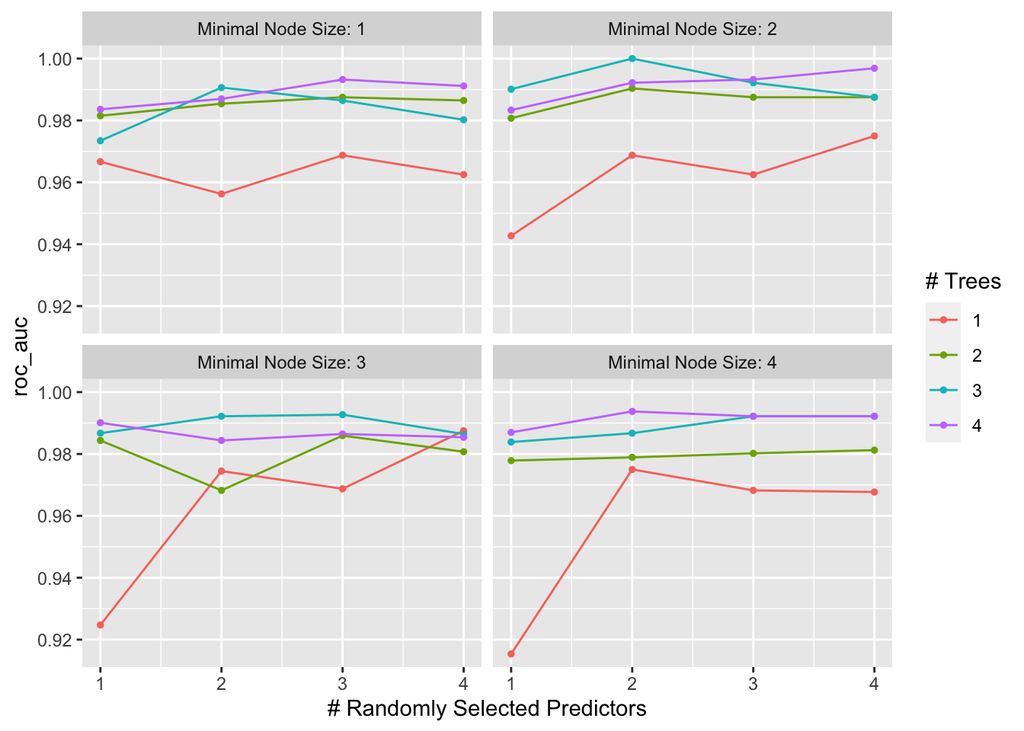

```r
autoplot(tune_res_forest)
```

#### Plot of knn

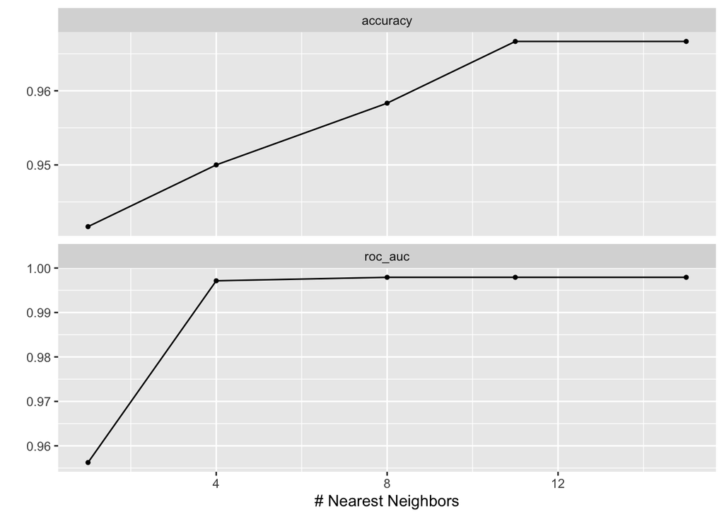

```r
autoplot(tune_res_knn)
```

```r
tune_lasso_roc <- augment(lasso_final_fit, new_data = iris_train) %>%
  roc_auc(species,.pred_0,.pred_1, .pred_2) %>%
  select(.estimate)

tune_boost_roc <- augment(final_fit_boost, new_data = iris_train) %>%
  roc_auc(species,.pred_0,.pred_1, .pred_2) %>%
  select(.estimate)

tune_rand_roc <- augment(random_final_fit, new_data = iris_train) %>%
  roc_auc(species,.pred_0,.pred_1, .pred_2) %>%
  select(.estimate)

tune_knn_roc <- augment(knn_final_fit, new_data = iris_train) %>%
  roc_auc(species,.pred_0,.pred_1, .pred_2) %>%
  select(.estimate)

model_roc <- c(tune_lasso_roc$.estimate,
                tune_boost_roc$.estimate,
                tune_rand_roc$.estimate,
                tune_knn_roc$.estimate)

iris_model_names <- c(
            "lasso",
            "boosted_tree",
            "random_forest",
            "knn")
model_results <- tibble(Model = iris_model_names,
                        roc_auc = model_roc)

modelresults <- model_results %>%
  arrange(-model_roc)

modelresults
```

```
## # A tibble: 4 × 2
##   Model         roc_auc
##   <chr>           <dbl>
## 1 lasso            1.00
## 2 random_forest    1.00
## 3 boosted_tree     1.00
## 4 knn              1.00
```

We could find that lasso performs the best considering to train sets since it has 0.9991667 for roc_auc.

## 5.3 Best Model Results

```r
#lasso
lasso_pre <- predict(lasso_final_fit,new_data=iris_test,type="class")

auc_test_lasso<-augment(lasso_final_fit,new_data=iris_test) %>%
  roc_auc(species,.pred_0,.pred_1, .pred_2) %>%
  select(.estimate)

acc_test_lasso<-augment(lasso_final_fit,new_data=iris_test) %>%
  accuracy(truth=species,estimate=.pred_class)

roc_lasso_curve <- augment(lasso_final_fit,new_data=iris_test) %>%
  roc_curve(species,.pred_0,.pred_1, .pred_2)

lasso <- autoplot(roc_lasso_curve)

#boosted tree
boost_pre <- predict(final_fit_boost,new_data=iris_test,type="class")

auc_test_boost<-augment(final_fit_boost,new_data=iris_test) %>%
  roc_auc(species,.pred_0,.pred_1, .pred_2) %>%
  select(.estimate)

acc_test_boost<-augment(final_fit_boost,new_data=iris_test) %>%
  accuracy(truth=species,estimate=.pred_class)

roc_boost_curve <- augment(final_fit_boost,new_data=iris_test) %>%
  roc_curve(species,.pred_0,.pred_1, .pred_2)

boost <- autoplot(roc_boost_curve)

#random forest
rand_pre <- predict(random_final_fit,new_data=iris_test,type="class")

auc_test_rand<-augment(random_final_fit,new_data=iris_test) %>%
  roc_auc(species,.pred_0,.pred_1, .pred_2) %>%
  select(.estimate)

acc_test_rand<-augment(random_final_fit,new_data=iris_test) %>%
  accuracy(truth=species,estimate=.pred_class)

roc_rand_curve <- augment(random_final_fit,new_data=iris_test) %>%
  roc_curve(species,.pred_0,.pred_1, .pred_2)

random <- autoplot(roc_rand_curve)

#knn
knn_pre <- predict(knn_final_fit,new_data=iris_test,type="class")

auc_test_knn<-augment(knn_final_fit,new_data=iris_test) %>%
  roc_auc(species,.pred_0,.pred_1, .pred_2) %>%
  select(.estimate)

acc_test_knn<-augment(knn_final_fit,new_data=iris_test) %>%
  accuracy(truth=species,estimate=.pred_class)

roc_knn_curve <- augment(knn_final_fit,new_data=iris_test) %>%
  roc_curve(species,.pred_0,.pred_1, .pred_2)

knn <- autoplot(roc_knn_curve)
```

#### 5.4 Plot the graphs of four models roc curve:

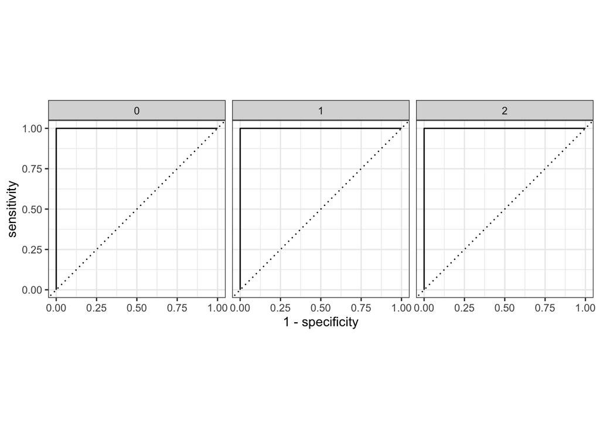

```r
lasso
```

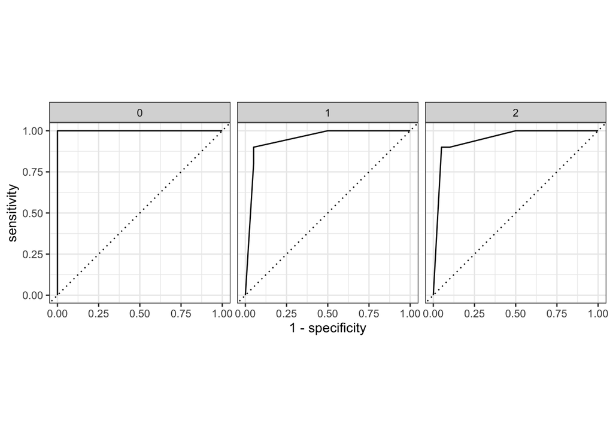

```r
boost
```

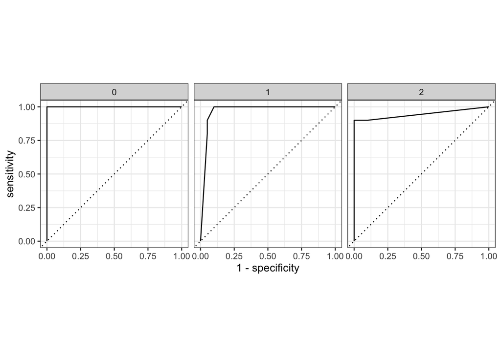

```r
random
```

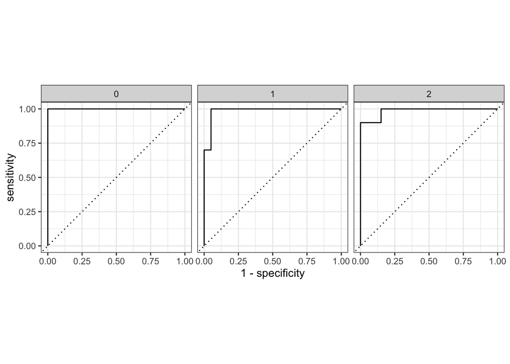

```r
knn
```

#### 5.5 Plot the graphs of four models roc curve for test set:

```r
result_auc <- c(auc_test_lasso$.estimate,
                auc_test_boost$.estimate,
                auc_test_rand$.estimate,
                auc_test_knn$.estimate)

iris_mod_names <- c(
            "lasso",
            "boost",
            "random forest",
            "knn")
model_test <- tibble(Model = iris_mod_names,
                        roc_auc = result_auc)

model_test
```

```
## # A tibble: 4 × 2
##   Model         roc_auc
##   <chr>           <dbl>
## 1 lasso           1
## 2 boost           0.965
## 3 random forest   0.971
## 4 knn             0.99
```

#### 5.6 Plot the graphs of four models acc curve for test set:

```r
result_acc <- c(acc_test_lasso$.estimate,
                acc_test_boost$.estimate,
                acc_test_rand$.estimate,
                acc_test_knn$.estimate)

iris_acc_test <- tibble(Model = iris_mod_names,
                        Accuracy = result_acc)

iris_acc_test
```

```
## # A tibble: 4 × 2
##   Model         Accuracy
##   <chr>            <dbl>
## 1 lasso            0.933
## 2 boost            0.9
## 3 random forest    0.933
## 4 knn              0.9
```

We could find that lasso and random forest performs the best considering to test sets since it has 0.9333333for acc.

# 6.Conclusion

After constructing lasso regression, boost tree, random-forest and knn to the train data sets and test data sets, we decide to use lasso regression to fit our iris data. That’s because lasso regression preforms the best both in training sets and test sets.